# JLC 445/696 Final Project Template

### 1-2 Maps

- Get the city outline and roads

```r
dc.roads <- roads("DC", "District of Columbia")
dc.roads.major <- dc.roads %>%  filter(RTTYP %in% c("I","S","U"))
dc.outline <- county_subdivisions("DC", "District of Columbia")
```

- Choose a hotspot method
- Facet by month

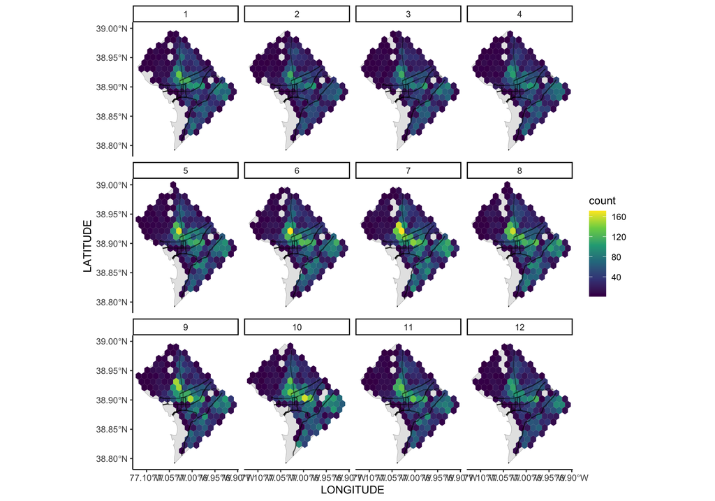

```r
ggplot() +
  geom_sf(data = dc.outline, color = "grey") +
  geom_hex(aes(x = LONGITUDE, y = LATITUDE), data = dc.subset, bins = 16) +
  scale_fill_continuous(type = "viridis") +
  geom_sf(data = dc.roads.major, color = "black", alpha = 0.4) +
  theme_classic() +
  facet_wrap(~ MONTH)
```

[THE SOURCE CODE FOR THIS FILE WE CREATED IN CLASS ON 12/4/2024 CAN BE FOUND HERE](https://github.com/matthew-danna/crime-analysis/blob/main/JLC%20445%20696/Final%20Project/JLC%20445%20696%20Final%20Project%202024%2012%2004.Rmd)